# Tweaking display items: IFN trial figures

**J. Taroni 2018**

We’ll use a series of notebooks, separate from the analysis notebooks, to tweak display items. In this notebook, I’ll work with the IFN trial data.

## Install `ggsignif`

```r
# devtools::install_url("https://cran.r-project.org/src/contrib/ggsignif_0.4.0.tar.gz")
```

## Set up

```r
# we're setting this to the top level directory for this project because
# we'll need to access the data and results directories
# the rationale is to keep the notebooks required for tweaking figures separate
# from the analysis notebooks
knitr::opts_knit$set(root.dir = "..")
```

```r
`%>%` <- dplyr::`%>%`
```

```r
plot.dir <- file.path("figure_notebooks", "figures")
dir.create(plot.dir, showWarnings = FALSE, recursive = TRUE)
```

## IFN-K trial

### Plot functions

```r
# intended to be used in this environment only
# Baseline figure
BaselinePlot <- function(df,
                         y.var = "Value",
                         facet.formula = "~ LV",
                         y.label = "LV expression") {
  # df: data.frame from 09-sle_ifn_data_prep
  # y.var: name of y variable passed to ggplot2::aes_string
  # facet.formula: passed to ggplot2::facet_grid
  # y.label: y-axis label
  ggplot2::ggplot(df,
                  ggplot2::aes(interaction(`Disease state`, `IFN-level`),
                                      colour = `IFN-level`)) +
    ggplot2::geom_jitter(ggplot2::aes_string(y = y.var), width = 0.2) +
    ggplot2::stat_summary(ggplot2::aes_string(y = y.var),
                          fun.y = "median", size = 4, shape = 18,
                          geom = "point", color = "black", alpha = 0.7) +
    ggplot2::facet_grid(as.formula(facet.formula)) +
    ggplot2::theme_bw() +
    ggplot2::theme(axis.text.x = ggplot2::element_text(angle = 45, hjust = 1),
                   text = ggplot2::element_text(size = 15),
                   legend.position = "none",
                   plot.margin = ggplot2::margin(t = 5, r = 50, b = 5, l = 5,
                                                 unit = "pt"),
                   plot.title = ggplot2::element_text(hjust = 0.5)) +
    ggplot2::labs(x = "interaction(Disease state, IFN-level)", y = y.label,
                  title = "Baseline") +
    ggplot2::scale_colour_manual(values = c("#5C5C5C", "#8073ac",
                                            "#e08214", "#969696")) +
    ggplot2::scale_x_discrete(labels = c("Healthy control", "SLE IFN-negative",
                                         "SLE IFN-positive", "SLE Placebo"))
}
# Day 112 plot (one variable -- module or LV)
Day112Plot <- function(df,
                       filt.var = NULL,
                       y.limit = c(-0.4, 0.4),
                       y.label = "change in LV") {
  # df: data.frame from 10-sle_ifn_analysis
  # filt.var: name of the variable that was used to filter, used for title only
  # y.limit: y-axis limits passed to ggplot2::ylim
  # y.label: y-axis label
  df %>%
    ggplot2::ggplot(ggplot2::aes(x = `IFN-level`, y = `Change`,
                                 colour = `IFN-level`)) +
    ggplot2::geom_boxplot() +
    ggplot2::geom_jitter(alpha = 0.5, width = 0.2) +
    ggplot2::theme_bw() +
    ggplot2::theme(axis.text.x = ggplot2::element_text(angle = 45, hjust = 1),
                   legend.position = "none",
                   text = ggplot2::element_text(size = 15),
                   plot.margin = ggplot2::margin(5, 25, 5, 5),
                   plot.title = ggplot2::element_text(hjust = 0.5)) +
    ggplot2::ylim(y.limit) +
    ggplot2::labs(y = y.label,
                  title = paste(filt.var, "Day 112 of IFN-K treatment")) +
    ggplot2::scale_color_manual(values = c("#8073ac", "#e08214", "#969696")) +
    ggsignif::geom_signif(comparisons = list(c("Placebo", "IFN-positive")),
                          color = "#000000")
}
```

### MultiPLIER

```r
b.file <- file.path("results", "09", "E-GEOD-39088_recount2_PLIER_IFN_B.tsv")
b.df <- readr::read_tsv(b.file)
```

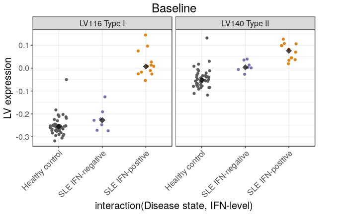

```r
baseline.p <- b.df %>%
  dplyr::filter(!Day %in% c("day 112", "day 168"),
                !Group %in% c("Control, stimulated", "Placebo")) %>%
  dplyr::mutate(`IFN-level` =
                  dplyr::if_else(`Disease state` == "healthy",
                                 true = "Control",
                                 false = `IFN-level`),
                LV =
                  dplyr::case_when(
                    LV == "LV116" ~ "LV116 Type I",
                    LV == "LV140" ~ "LV140 Type II")
                ) %>%
  BaselinePlot()
baseline.p
```

```r
lv.change.file <- file.path("results", "10",
                            "E-GEOD-39088_IFNk_recount2_PLIER_change.tsv")
lv.change.df <- readr::read_tsv(lv.change.file)
```

`LV116` has the highest AUC (`AUC = 0.937`) for IFN-alpha/beta signaling in this model.

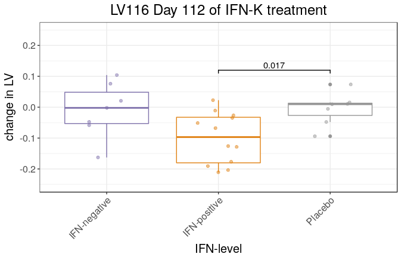

```r
lv116.p <- lv.change.df %>%
  dplyr::filter(LV == "LV116",
                Day == "day 112") %>%
  Day112Plot(filt.var = "LV116", y.limit = c(-0.25, 0.25))
lv116.p
```

```r
p <- cowplot::plot_grid(baseline.p, lv116.p, align = "h", axis = "b",
                        rel_widths = c(1.5, 1), labels = c("A", "B"))
p.title <- cowplot::ggdraw() +
  cowplot::draw_label("MultiPLIER", fontface = "bold",
                      size = 20)
multi.p <- cowplot::plot_grid(p.title, p, ncol = 1, rel_heights = c(0.1, 1))
```

```r
rm(b.df, lv.change.df, lv116.p, baseline.p, p, p.title)
```

### Modular framework

First, we’ll take a look at the IFN-K trial.

```r
mod.file <- file.path("results", "09", "E-GEOD-39088_Chiche_et_al_module.tsv")
mod.df <- readr::read_tsv(mod.file)
```

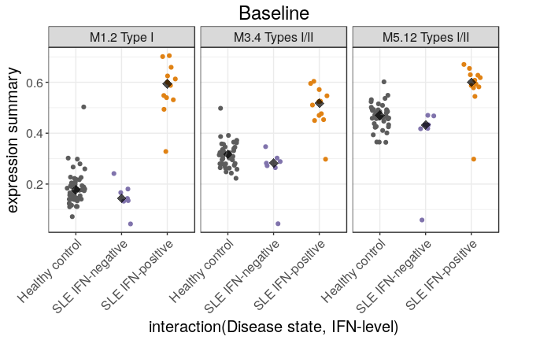

```r
baseline.p <- mod.df %>%
  dplyr::filter(!Day %in% c("day 112", "day 168"),
                !Group %in% c("Control, stimulated", "Placebo")) %>%
  dplyr::mutate(`IFN-level` =
                  dplyr::if_else(`Disease state` == "healthy",
                                 true = "Control",
                                 false = `IFN-level`),
                Module =
                  dplyr::case_when(
                    Module == "M1.2" ~ "M1.2 Type I",
                    Module == "M3.4" ~ "M3.4 Types I/II",
                    Module == "M5.12" ~ "M5.12 Types I/II")
                ) %>%
  BaselinePlot(y.var = "Summary", facet.formula = "~ Module",
               y.label = "expression summary")
baseline.p
```

We’ll analyze the differences between IFN-positive and Placebo groups change in `M1.2` expression on `day 112` further.

```r
mod.change.file <- file.path("results", "10",
                             "E-GEOD-39088_IFNk_Chiche_modules_change.tsv")
mod.change.df <- readr::read_tsv(mod.change.file)
```

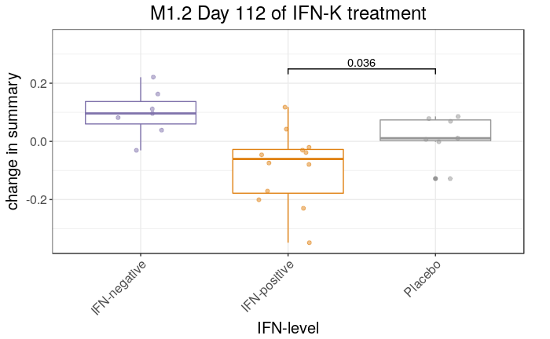

```r
m1.p <- mod.change.df %>%
  dplyr::filter(Module == "M1.2",
                Day == "day 112") %>%
  Day112Plot(filt.var = "M1.2", y.limit = c(-0.35, 0.35),
             y.label = "change in summary")
m1.p
```

```r
p <- cowplot::plot_grid(baseline.p, m1.p, align = "h", axis = "b",
                        rel_widths = c(1.5, 1), labels = c("C", "D"))
p.title <- cowplot::ggdraw() +
  cowplot::draw_label("Whole Blood Modular Framework", fontface = "bold",
                      size = 20)
mod.p <- cowplot::plot_grid(p.title, p, ncol = 1, rel_heights = c(0.1, 1))
```

```r
rm(baseline.p, p, p.title, m1.p)
```

### SLE WB PLIER

```r
b.file <- file.path("results", "09", "E-GEOD-39088_SLE-WB_PLIER_IFN_B.tsv")
b.df <- readr::read_tsv(b.file)
```

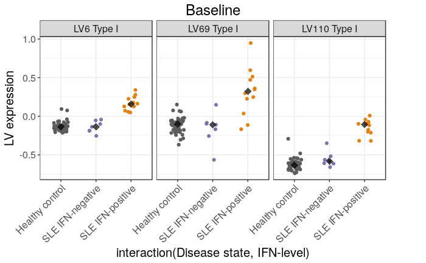

```r
baseline.p <- b.df %>%
  dplyr::filter(!Day %in% c("day 112", "day 168"),
                !Group %in% c("Control, stimulated", "Placebo")) %>%
  dplyr::mutate(`IFN-level` =
                  dplyr::if_else(`Disease state` == "healthy",
                                 true = "Control",
                                 false = `IFN-level`),
                LV =
                  dplyr::case_when(
                    LV == "LV6" ~ "LV6 Type I",
                    LV == "LV69" ~ "LV69 Type I",
                    LV == "LV110" ~ "LV110 Type I")
                ) %>%
  dplyr::mutate(LV = factor(LV, levels = c("LV6 Type I", "LV69 Type I",
                                           "LV110 Type I"))) %>%
  BaselinePlot()
baseline.p
```

```r
lv.change.file <- file.path("results", "10",
                            "E-GEOD-39088_IFNk_SLE_PLIER_change.tsv")
lv.change.df <- readr::read_tsv(lv.change.file)
```

`LV6` from this model has highest AUC (`AUC = 0.973`) for IFN-alpha/beta signaling.

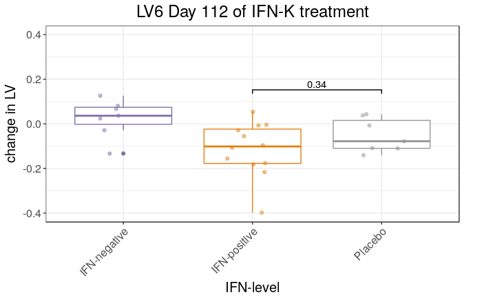

```r
lv6.p <- lv.change.df %>%
  dplyr::filter(LV == "LV6",
                Day == "day 112") %>%
  Day112Plot(filt.var = "LV6")
lv6.p
```

Let’s check `LV110` for differential expression even though it may be better capturing another signal (e.g., macrophages).

```r
lv110.df <- lv.change.df %>%
  dplyr::filter(LV == "LV110",
                Day == "day 112",
                `IFN-level` != "IFN-negative")
wilcox.test(lv110.df$Change ~ lv110.df$Group)
```

```
    Wilcoxon rank sum test

data:  lv110.df$Change by lv110.df$Group
W = 15, p-value = 0.02211
alternative hypothesis: true location shift is not equal to 0
```

```r
p <- cowplot::plot_grid(baseline.p, lv6.p, align = "h", axis = "b",
                        rel_widths = c(1.5, 1), labels = c("E", "F"))
p.title <- cowplot::ggdraw() +
  cowplot::draw_label("SLE WB PLIER", fontface = "bold",
                      size = 20)
sle.p <- cowplot::plot_grid(p.title, p, ncol = 1, rel_heights = c(0.1, 1))
```

```r
overall.p <- cowplot::plot_grid(multi.p, mod.p, sle.p, ncol = 1, scale = 0.9)
ggplot2::ggsave(file.path(plot.dir, "IFN-K_supplemental.pdf"), plot = overall.p,
                width = 11, height = 14)
```

```r
rm(list = setdiff(ls(), c("%>%", "plot.dir")))
```

## AMG 811 Trial

This is the trial where we expect Type II interferon to be perturbed.

### Plotting function

```r
PlotInteraction <- function(df, plot.title, y.var = "Value", wrap.var = "LV",
                            y.label = "LV value") {
  ggplot2::ggplot(df,
                  ggplot2::aes(x = interaction(`Disease state`, `Day`),
                               fill = interaction(`Disease state`, `Day`))) +
    ggplot2::geom_boxplot(ggplot2::aes_string(y = y.var)) +
    ggplot2::geom_point(ggplot2::aes_string(y = y.var),
                        alpha = 0.3, position = "jitter") +
    ggplot2::facet_wrap(as.formula(paste("~", wrap.var))) +
    ggplot2::theme_bw() +
    ggplot2::theme(axis.text.x = ggplot2::element_text(angle = 45, hjust = 1),
                   legend.position = "none",
                   text = ggplot2::element_text(size = 15),
                   plot.title = ggplot2::element_text(hjust = 0.5,
                                                      face = "bold"),
                   plot.subtitle = ggplot2::element_text(hjust = 0.5)) +
    ggplot2::labs(x = "interaction(Disease state, Day)",
                  y = y.label,
                  title = plot.title,
                  subtitle = "Treatment with AMG 811") +
    ggplot2::scale_fill_manual(values = c("seagreen3", "#deebf7", "#9ecae1",
                                          "#3182bd", "white")) +
    ggplot2::scale_x_discrete(labels = c("healthy", "SLE baseline",
                                         "SLE day 15", "SLE day 56",
                                         "SLE EOS"))
}
```

### MultiPLIER

```r
b.file <- file.path("results", "09", "E-GEOD-78193_recount2_PLIER_IFN_B.tsv")
b.df <- readr::read_tsv(b.file)
```

```r
multi.p <- b.df %>%
  dplyr::mutate(LV = dplyr::case_when(
    LV == "LV116" ~ "LV116 Type I",
    LV == "LV140" ~ "LV140 Type II"
  )) %>%
  PlotInteraction(plot.title ="MultiPLIER")
```

```r
rm(b.file, b.df)
```

### Modular framework

```r
mod.file <- file.path("results", "09", "E-GEOD-78193_Chiche_et_al_module.tsv")
mod.df <- readr::read_tsv(mod.file)
```

```r
mod.p <- mod.df %>%
  dplyr::mutate(Module = dplyr::case_when(
    Module == "M1.2" ~ "M1.2 Type I",
    Module == "M3.4" ~ "M3.4 Types I/II",
    Module == "M5.12" ~ "M5.12 Types I/II"
  )) %>%
  PlotInteraction(plot.title = "Whole Blood Modular Framework",
                  y.var = "Summary", wrap.var = "Module",
                  y.label = "expression summary")
```

```r
rm(mod.df, mod.file)
```

### SLE WB PLIER

```r
b.file <- file.path("results", "09", "E-GEOD-78193_SLE-WB_PLIER_IFN_B.tsv")
b.df <- readr::read_tsv(b.file)
```

```r
sle.p <- b.df %>%
  dplyr::mutate(LV = dplyr::case_when(
    LV == "LV6" ~ "LV6 Type I",
    LV == "LV69" ~ "LV69 Type I",
    LV == "LV110" ~ "LV110 Type I"
  )) %>%
  dplyr::mutate(LV = factor(LV, levels = c("LV6 Type I", "LV69 Type I",
                                           "LV110 Type I"))) %>%
  PlotInteraction(plot.title = "SLE WB PLIER")
```

```r
p <- cowplot::plot_grid(multi.p, mod.p, sle.p, nrow = 3, scale = 0.95)
ggplot2::ggsave(file.path(plot.dir, "AMG811_supplemental.pdf"), width = 6,
                height = 14)
```